# drugi_zadatak

Fran Lubina, Zvonimir Stracenski, Luka Varga, Karlo Vešligaj

2025-12-17

#Pitanje 2: Postoji li statistički značajna razlika u gradskoj potrošnji automobila između različitih kontinenata proizvodača?

```r
grouped <- group_by(my_cars, continent)

summary.result1 <- summarise(
  grouped,
  count = n(),
  mean_city = mean(city.L.100km, na.rm = TRUE),
  median_city = median(city.L.100km, na.rm = TRUE),
  sd_city = sd(city.L.100km, na.rm = TRUE),
  min_city = min(city.L.100km, na.rm = TRUE),
  max_city = max(city.L.100km, na.rm = TRUE),
  q25 = quantile(city.L.100km, 0.25, na.rm = TRUE),
  q75 = quantile(city.L.100km, 0.75, na.rm = TRUE)
)
summary.result1
```

```
## # A tibble: 3 × 9
##   continent    count mean_city median_city sd_city min_city max_city   q25   q75
##   <chr>        <int>     <dbl>       <dbl>   <dbl>    <dbl>    <dbl> <dbl> <dbl>
## 1 Asia           107      9.12        8.7     2.04     4.8      14.7  7.58  9.79
## 2 Europe          74     11.5        11.2     2.48     6.35     18.1  9.79 12.9
## 3 North Ameri…    20      8.46        7.58    2.19     5        12.4  7.27  9.79
```

Tablica prikazuje mjere centralne tendencije gradske potrošnje automobila grupiranih po kontinentu proizvođača. Može se uočiti kako se aritmetička sredina i medijan gradske potrošnje razlikuju među kontinentima.

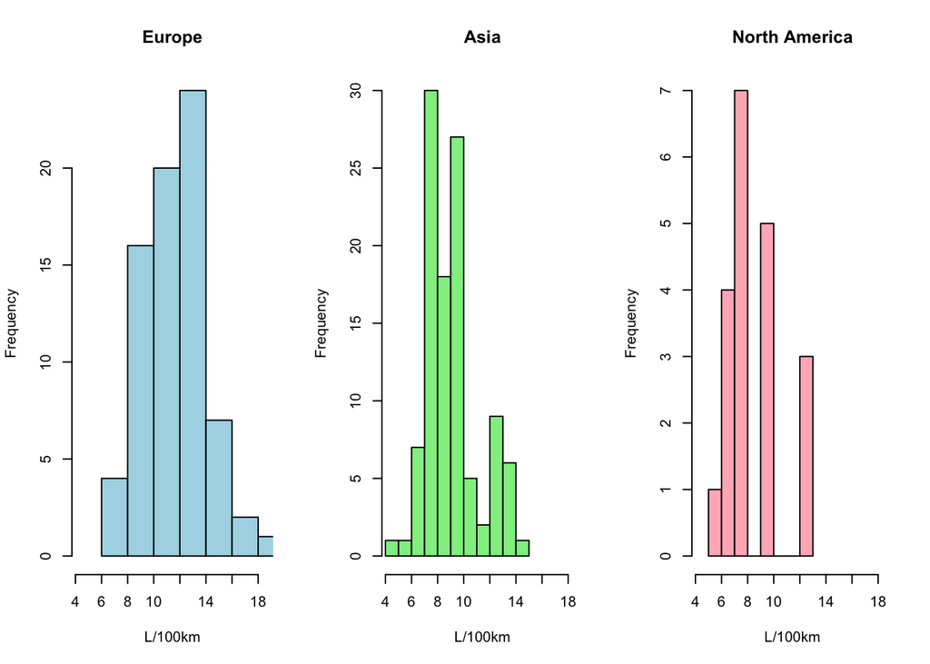

```r
xrange <- range(my_cars$city.L.100km) + c(-0.5, 0.5)
ymax <- max(
  hist(my_cars[my_cars$continent == "Europe", ]$city.L.100km, plot = FALSE)$counts,
  hist(my_cars[my_cars$continent == "Asia", ]$city.L.100km, plot = FALSE)$counts,
  hist(my_cars[my_cars$continent == "North America", ]$city.L.100km, plot = FALSE)$counts
)

par(mfrow = c(1, 3))

hist(my_cars[my_cars$continent == "Europe", ]$city.L.100km,
     main = "Europe",
     xlab = "L/100km",
     ylab = "Frequency",
     col = "lightblue",
     border = "black",
     xlim = xrange)

hist(my_cars[my_cars$continent == "Asia", ]$city.L.100km,
     main = "Asia",
     xlab = "L/100km",
     ylab = "Frequency",
     col = "lightgreen",
     border = "black",
     xlim = xrange)

hist(my_cars[my_cars$continent == "North America", ]$city.L.100km,
     main = "North America",
     xlab = "L/100km",
     ylab = "Frequency",
     col = "lightpink",
     border = "black",
     xlim = xrange)
```

Ova tri histograma prikazuju raspodjelu automobila po gradskoj potrošnji, pri čemu svaki histogram predstavlja jedan od kontinenata. Iz prikaza je jasno vidljiva razlika u potrošnji, osobito za Europu, gdje je gradska potrošnja, prema ovom uzorku, znatno viša u odnosu na Sjevernu Ameriku i Aziju.

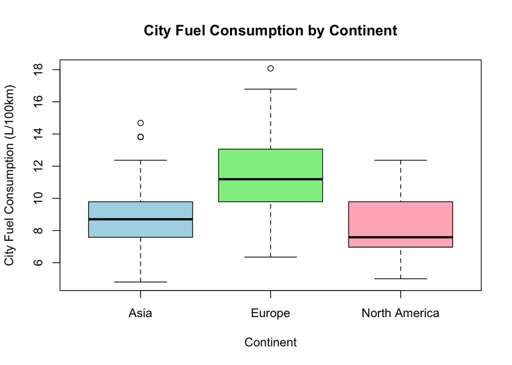

```r
boxplot(city.L.100km ~ continent, data = my_cars,
        main = "City Fuel Consumption by Continent",
        xlab = "Continent",
        ylab = "City Fuel Consumption (L/100km)",
        col = c("lightblue", "lightgreen", "lightpink"))
```

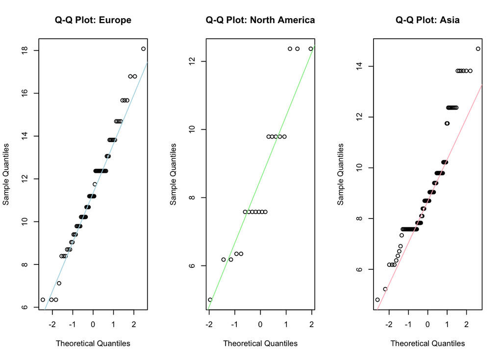

```r
par(mfrow = c(1, 3))

qqnorm(my_cars$city.L.100km[my_cars$continent == "Europe"],
       main = "Q-Q Plot: Europe",
       xlab = "Theoretical Quantiles",
       ylab = "Sample Quantiles")
qqline(my_cars$city.L.100km[my_cars$continent == "Europe"], col = "lightblue")

# Q-Q plot for North America
qqnorm(my_cars$city.L.100km[my_cars$continent == "North America"],
       main = "Q-Q Plot: North America",
       xlab = "Theoretical Quantiles",
       ylab = "Sample Quantiles")
qqline(my_cars$city.L.100km[my_cars$continent == "North America"], col = "lightgreen")

# Q-Q plot for Asia
qqnorm(my_cars$city.L.100km[my_cars$continent == "Asia"],
       main = "Q-Q Plot: Asia",
       xlab = "Theoretical Quantiles",
       ylab = "Sample Quantiles")
qqline(my_cars$city.L.100km[my_cars$continent == "Asia"], col = "lightpink")
```

Q-Q dijagrami prikazuju značajna odstupanja od normalne distribucije za proizvođače iz Sjeverne Amerike i Azije. Zbog toga moramo koristiti test koji ne pretpostavlja normalnost podataka. Zato koristimo Kruskal-Wallisov test koji je neparametarska alternativa ANOVA testu.

```r
my_cars$continent <- as.factor(my_cars$continent)
kruskal.test(city.L.100km ~ continent, data = my_cars)
```

```
##
##  Kruskal-Wallis rank sum test
##
## data:  city.L.100km by continent
## Kruskal-Wallis chi-squared = 49.079, df = 2, p-value = 2.201e-11
```

Zbog izrazito niske p-vrijednosti Kruskal-Wallisovog testa zaključujemo da ova tri skupa podatka ne proistječu iz iste distribucije, tj. da postoji razlika u gradskoj potrošnji između Azije, Europe i Sjeverne Amerike.

Zbog uočene sličnosti između Azije i Sjeverne Amerike provodimo Wilcoxov test kako bi usporedili samo ova dva kontinenta.

H0: Ne postoji razlika u gradskoj potrošnji između Azije i Sjeverne Amerike. H1: Postoji razlika u gradskoj potrošnji između Azije i Sjeverne Amerike.

```r
wilcox.test(city.L.100km ~ continent,
            data = subset(my_cars, continent %in% c("Asia", "North America")))
```

```
##
##  Wilcoxon rank sum test with continuity correction
##
## data:  city.L.100km by continent
## W = 1301, p-value = 0.1241
## alternative hypothesis: true location shift is not equal to 0
```

Rezultati pokazuju p-vrijednost veću od 0.05, što znači da ne odbacujemo H₀. Zaključujemo da se gradska potrošnja za Aziju i Sjevernu Ameriku vjerojatno ne razlikuje značajno i mogla bi proizlaziti iz iste distribucije.